# GED dynamic tabs example

Anthony Davidson, Emily Stringer and Mark Gingrass (original content)

2022-05-17

```
## [1] "AerialPaddock" "Airport"       "Bonshaw"       "Cookanalla"
## [5] "JerraEast"     "JerraWest"     "Majura"
```

# 1 Overview

Here are some old notes I found for creating dynamic tabs for a collection of sites. I have added notes to this document with a set of examples using the same site names but different data (just in case).

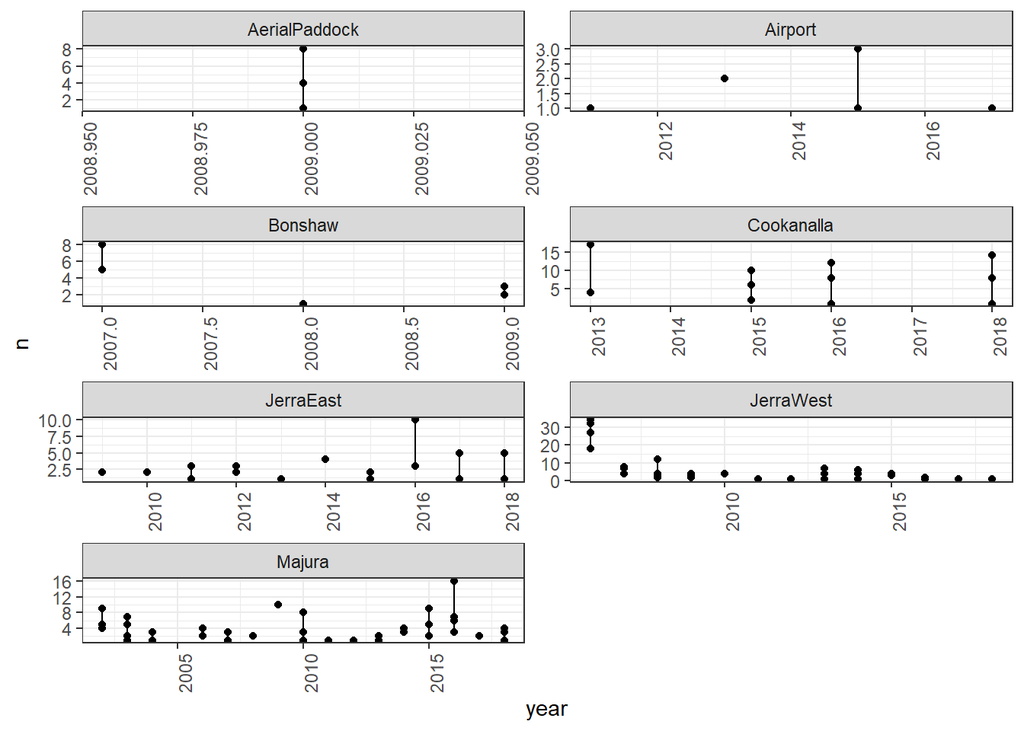

## 1.2 Insert iframe

This quick little shortcut helps with including dynamic content inside static web and html documents. You can also use `knitr::include_app` here in R code too but I find the html snippet below to work just as well inside a RMD file.

[video not shown]

> NOTE: the iframe outputs do not show up currently in the rendered RStudio window. You need to `Open in Browser` in top left corner of popout viewer in RStudio.

## 1.3 Tables in a static RMD

It is possible to create interactive datatables uses the javascript library using htmlwidgets I think. Anyways, it works in a RMD file like so:

|  | X | site | grid.id | year | recap | siteR | n |
| --- | --- | --- | --- | --- | --- | --- | --- |
| 1 | 1 | AerialPaddock | K | 2009 | 2 | 2 | 8 |
| 2 | 2 | AerialPaddock | L | 2009 | 1 | 2 | 4 |
| 3 | 3 | AerialPaddock | U | 2009 | 1 | 3 | 1 |
| 4 | 4 | Airport | NE | 2011 | 0 | 2 | 1 |
| 5 | 5 | Airport | NE | 2013 | 0 | 3 | 2 |
| 6 | 6 | Airport | NE | 2015 | 0 | 2 | 1 |
| 7 | 7 | Airport | NW | 2015 | 2 | 3 | 3 |
| 8 | 8 | Airport | NW | 2017 | 1 | 4 | 1 |
| 9 | 9 | Bonshaw | I | 2007 | 4 | 1 | 8 |
| 10 | 10 | Bonshaw | I | 2008 | 1 | 1 | 1 |

[output cut: 107 more lines]

## 1.4 Including code in RMDs

There are two main ways to do this currently, `child = <RMD>, results = "asis"` in the code chunk heading and using source in the chunk itself. Here I have included the resampling code below using source. Note the R script is in the `./R/` folder.

```r
source("R/resample_data_script.R", echo = TRUE)
```

> library(tidyverse)

> library(readxl)

> dat <- read_csv(“data/random_ged_resample1.csv”)

```
## -------------------------------------------------------- Delimiter: "," chr
## (2): site, grid.id dbl (5): ...1, year, recap, siteR, n
```

> glimpse(dat) Rows: 117 Columns: 7 $ …1 1, 2, 3, 4, 5, 6, 7, 8, 9, 10, 11, 12, 13, 14, 15, 16, 17, 18,~ $ site “AerialPaddock”, “AerialPaddock”, “AerialPaddock”, “Airport”, ~ $ grid.id “K”, “L”, “U”, “NE”, “NE”, “NE”, “NW”, “NW”, “I”, “I”, “I”, “J~ $ year 2009, 2009, 2009, 2011, 2013, 2015, 2015, 2017, 2007, 2008, 20~ $ recap 2, 1, 1, 0, 0, 0, 2, 1, 4, 1, 2, 4, 0, 2, 4, 2, 5, 12, 5, 6, 9~ $ siteR 8, 1, 1, 12, 8, 8, 1, 8, 17, 3, 4, 3, 4, 4, 34, 7, 16, 1, 2, 3~ $ n 8, 4, 1, 1, 2, 1, 3, 1, 8, 1, 3, 5, 1, 2, 6, 8, 8, 17, 10, 12,~

> dat1 <- dat %>% mutate(siteR = sample(n, replace = T))

> table(dat1$siteR == dat1$site)

FALSE 117

> dat2 <- dat1 %>% dplyr::select(site, grid.id, year, + recap, siteR, n)

> write.csv(dat2, “data/random_ged_resample2.csv”)  
> **Note** using `echo = TRUE` prints everything run and `include = TRUE` in the code snippet header prints the code iswell

# 2 Varying sites and grids

Here is a applied example of using dynamic tabs to represent a collection of plots. This can also be done with other R objects such as tables.

## 2.1 AerialPaddock

[[1]]

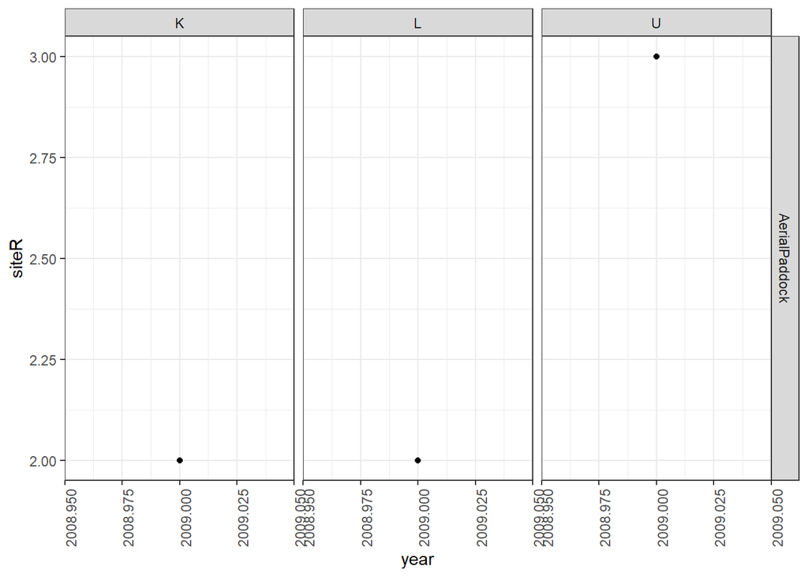

## 2.2 Airport

[[1]]

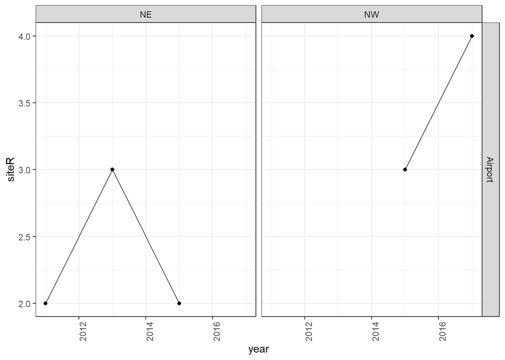

## 2.3 Bonshaw

[[1]]

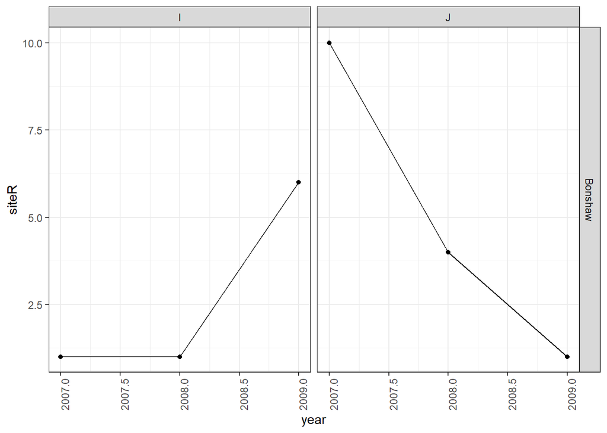

## 2.4 Cookanalla

[[1]]

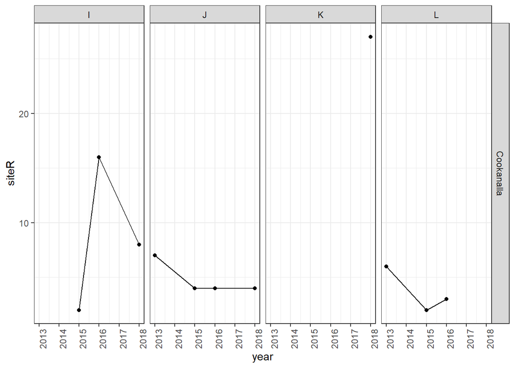

## 2.5 JerraEast

[[1]]

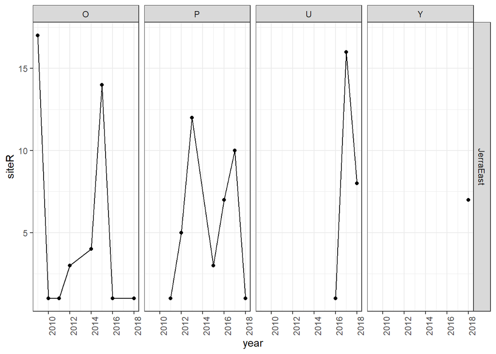

## 2.6 JerraWest

[[1]]

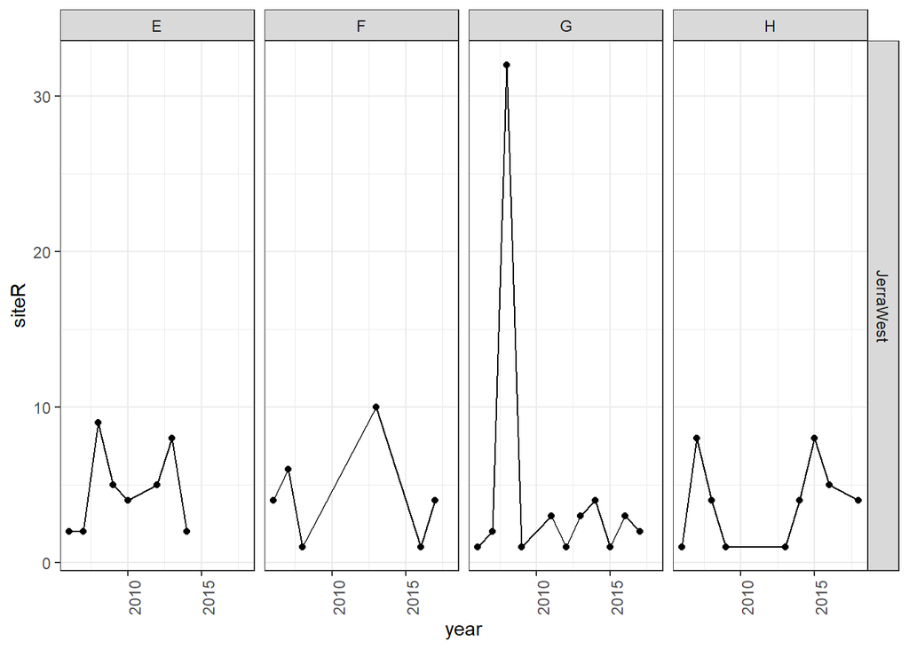

## 2.7 Majura

[[1]]

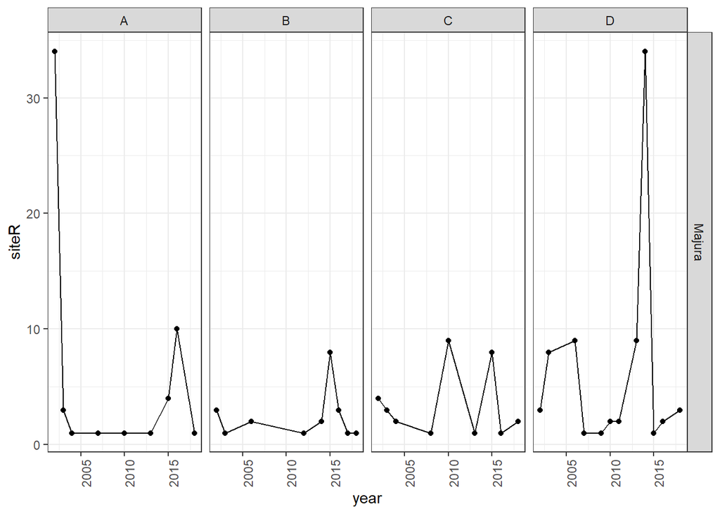

# 3 Another randomisation

Should be a difference and could be a good simple start to simulating differences between sites and grids given the observed differences in the sample data. This was originally what I thought would be helpful last time I bumped into you. Hopefully it helps. :)

## 3.1 AerialPaddock

[[1]]

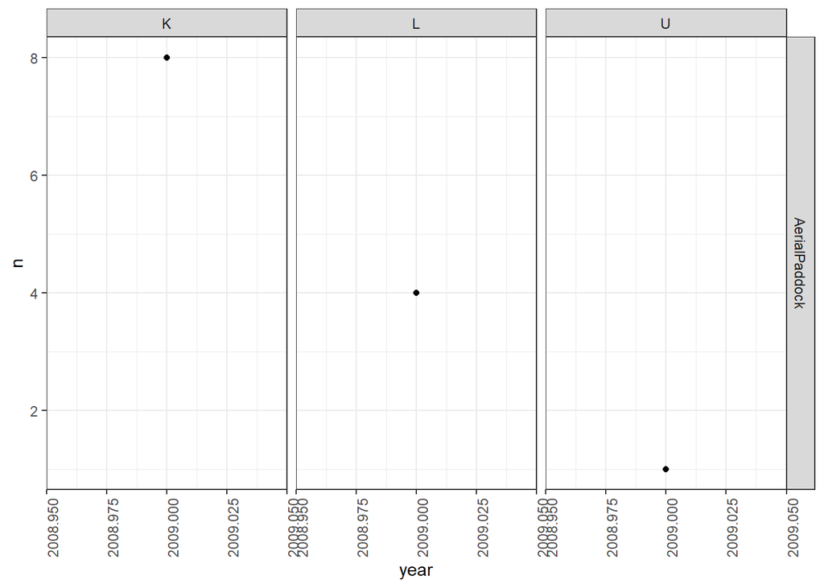

## 3.2 Airport

[[1]]

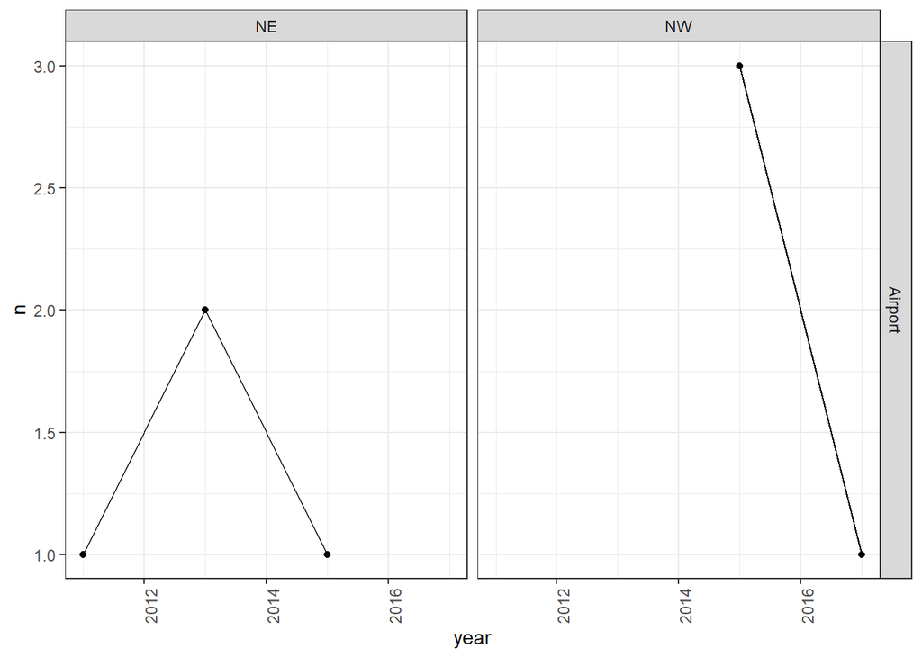

## 3.3 Bonshaw

[[1]]

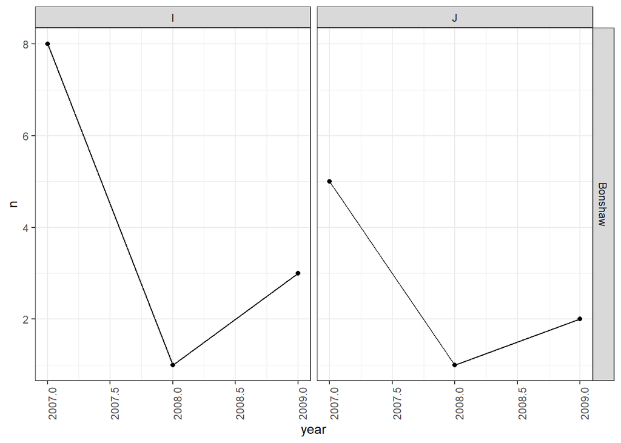

## 3.4 Cookanalla

[[1]]

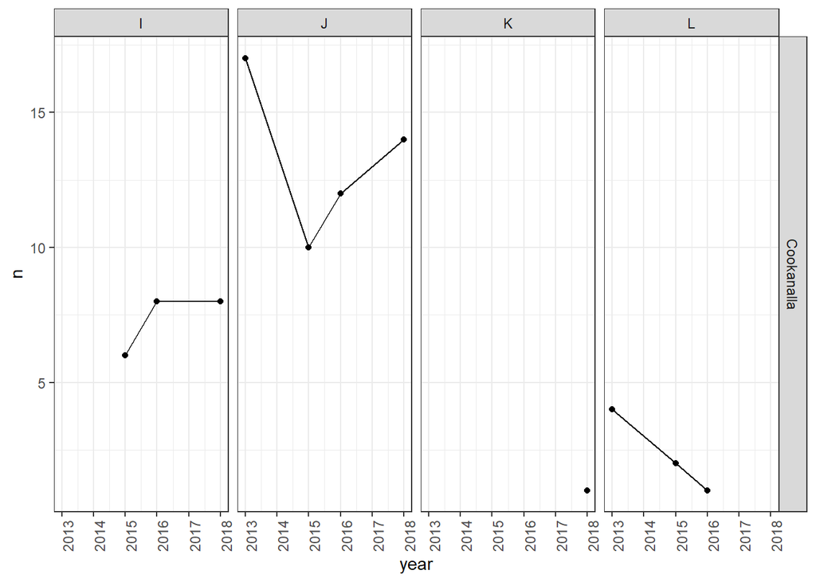

## 3.5 JerraEast

[[1]]

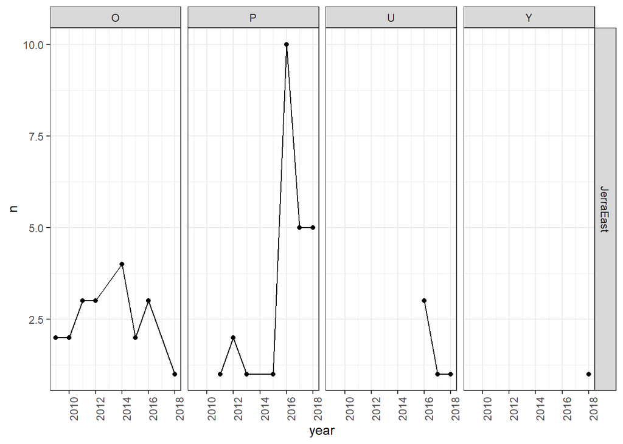

## 3.6 JerraWest

[[1]]

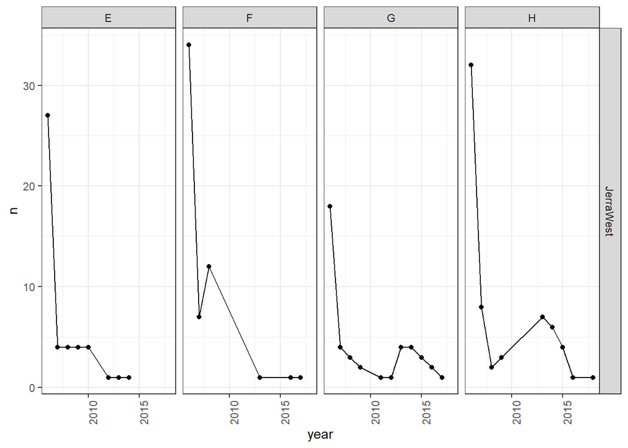

## 3.7 Majura

[[1]]

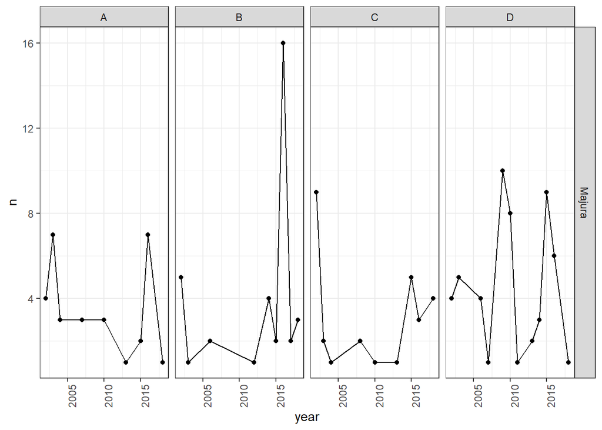